# Submitted data error checks

# 0. Instructions for submitters

Submitters should use this file to check for problems with submitted data. Each of these html files contains a summary of the data from a single submitted spreadsheet file. The html name is based on the name of the submitted file. Use the details below to check:

- Institute abbreviation, submitter and contributor names
- The plot location(s), using the map zoom and pan features if needed
- For problems in the first sections; “OK” means there are no problems in a particular section, “warning” is something that should be checked (but might be OK), “error” is a problem that needs to be addressed
- For numeric values outside the expected range in the “Value checks” section
- Variables with missing values–are there any missing that you thought you included?
- Plots of flux, cumulative emission over time, and final cumulative emission for strange patterns, unexpectedly high or low values
- Plots of weather data for appropriate differences between plots and expected diurnal or other patterns
- Plots of manure and application data for correct values

Finally, the numeric summary at the end might provide details that can help in pinpointing problems, but typically does not need to be checked.

# 1. Submitter

| inst.abbrev | submitter | version | date |
| --- | --- | --- | --- |
| AU | Pedersen, Johanna | 1 | 2022-07-07 |

# 2. Contributors

| contributor | institute |
| --- | --- |
| Nyord, Tavs | Aarhus Universitet |

# 3. File and directory names

```
## [1] "../../data-submitted/03/AU"
```

```
## [1] "../../data-submitted/03/AU/ALFAM2_template_5_2_211012_JP_18ABC.xlsx"
```

# 4. Location

[interactive chart not shown]

# 5.Keys and codes

## Codes in Treatments sheet

```
## OK
```

```
## OK
```

## Codes in Plots sheet

```
## OK
```

```
## OK
```

## Codes in Emission sheet

```
## OK
```

```
## OK
```

## Code merge check (matching project, experiment, field, plot, treatment)

```
## OK
```

```
## OK
```

```
## OK
```

```
## OK
```

```
## OK
```

# 6. Publication info

## Check for missing codes

```
## OK
```

```
## OK
```

## Complete citations given

```
## OK
```

```
## OK
```

# 7. Emission sheet

## Duplicated intervals

```
## OK
```

## Missing incorporation time

```
## OK
```

## Delay after application

```
## OK
```

## Missing or double interval number

```
## OK
## OK
## OK
## OK
## OK
## OK
## OK
## OK
## OK
## OK
## OK
## OK
## OK
## OK
## OK
## OK
## OK
## OK
## OK
## OK
## OK
## OK
## OK
## OK
## OK
## OK
## OK
```

## Missing time between intervals

```
## OK
## OK
## OK
## OK
## OK
## OK
## OK
## OK
## OK
## OK
## OK
## OK
## OK
## OK
## OK
## OK
## OK
## OK
## OK
## OK
## OK
## OK
## OK
## OK
## OK
## OK
## OK
```

## Measurement method and units

Measurement technique:

| Method | Frequency |
| --- | --- |
| Wind tunnel | 1788 |

Measurement technique classification:

| Classification | Frequency |
| --- | --- |
| wt | 1788 |

Emission units and conversion factors.

|  | Original unit | Conversion factor applied | Final unit |
| --- | --- | --- | --- |
| 1 | kg N/ha-hr | 1 | kg N/ha-hr |
| 465 | NA | NA | kg N/ha-hr |

# 7. Value checks

Check to see if submitted values are within a reasonable range.

## Weather

```
## wind : OK
## rain.rate : OK
## air.temp : OK
## soil.temp : OK
## soil.temp.surf : No values to check.
## air.temp.z : OK
## wind.z : OK
```

## Manure and application

```
## man.stor : No values to check.
## man.dm : OK
## man.vs : No values to check.
## man.tkn : OK
## man.tan : OK
## man.tic : No values to check.
## man.ua : No values to check.
## man.vfa : OK
## man.ph : OK
## app.rate : OK
## crop.z : No values to check.
```

## Emission

```
## j.NH3 : OK
## e.int : OK
## e.rel : OK
```

# 8. Missing values

Check for missing values.

## All variables

```
## Some values missing:
## Table below has number of missing observations by variable:
##   meas.tech.det       soil.type    soil.water.v      soil.moist  man.source.det
##            1788            1788            1788            1788            1788
##         man.bed        man.stor          man.vs         man.tic          man.ua
##            1788            1788            1788            1788            1788
##     time.incorp        man.area        dist.inj        furrow.z        furrow.w
##            1788            1788            1788            1788            1788
##          crop.z       crop.area             lai      notes.plot        man.trt3
##            1788            1788            1788            1739            1788
##           bg.dl          bg.val         bg.unit         pH.surf      air.temp.z
##            1788               9               9            1788               9
##     soil.temp.z  soil.temp.surf             rad             MOL           ustar
##               9            1788            1788            1788            1788
##              rl        air.pres   air.pres.unit              rh        wind.loc
##            1788            1788            1788            1788            1788
##         far.loc       notes.int j.NH3.unit.orig      j.NH3.orig j.NH3.conv.fact
##            1788            1787               9               9               9
##      soil.type2          exper2            rep2
##            1788            1788            1788
```

## Application method and measurement method

```
## OK
```

```
## OK
```

# 9. Plots

## Calculated cumulative emission

Cumulative emission. Missing values imputed (linear interpolation).

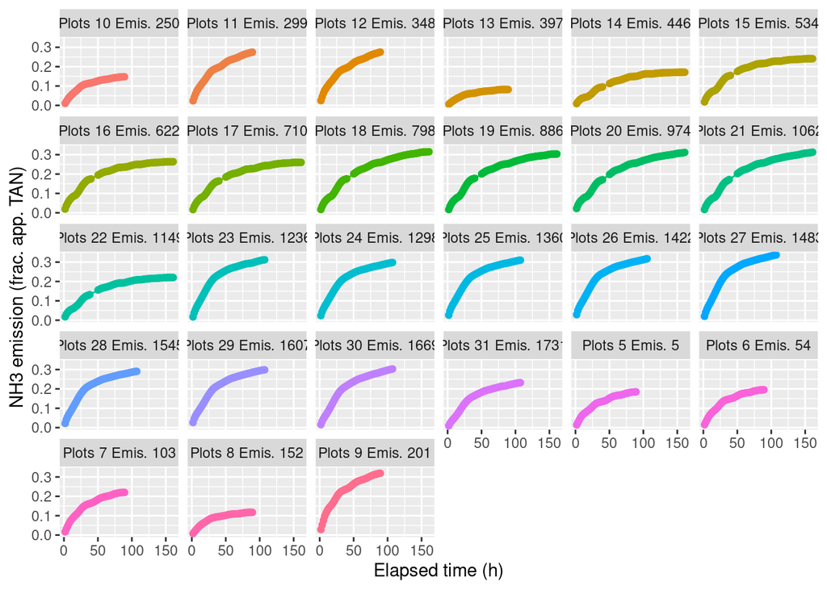

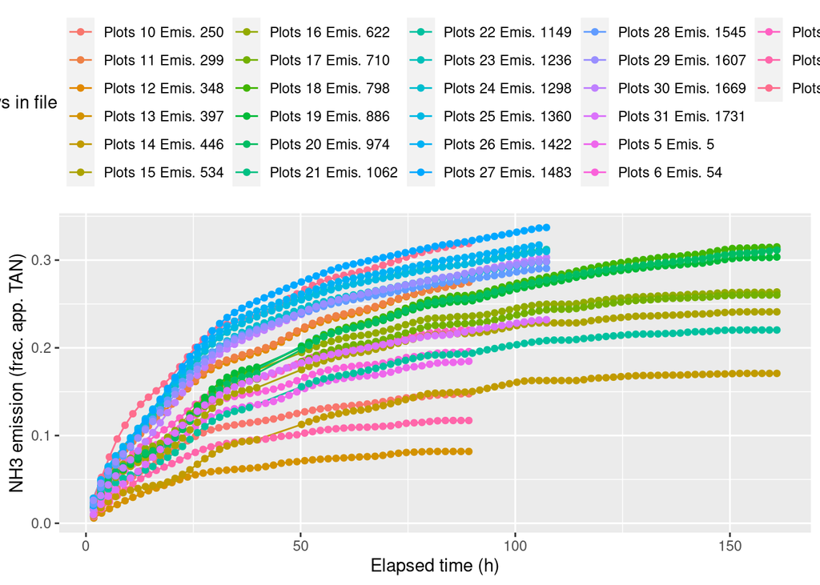

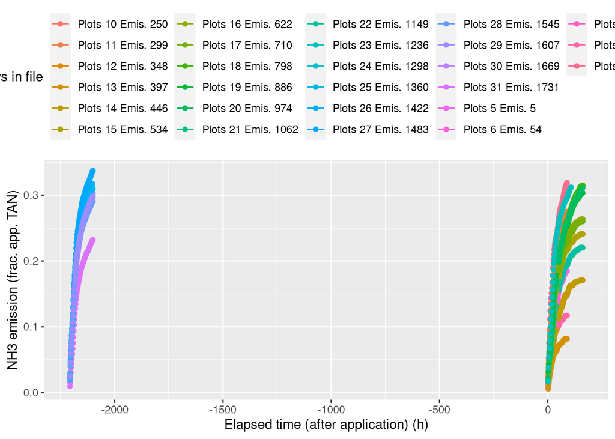

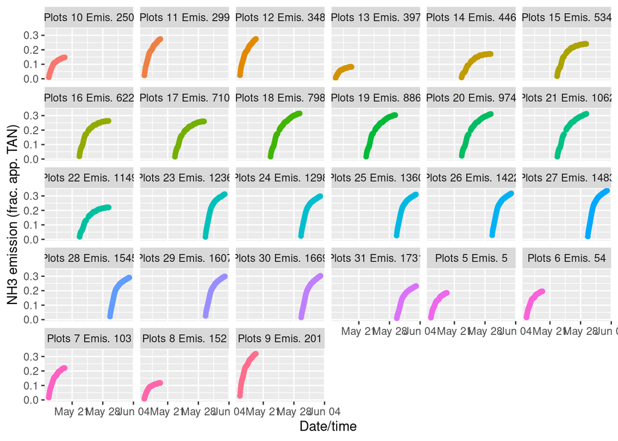

## Final cumulative emission

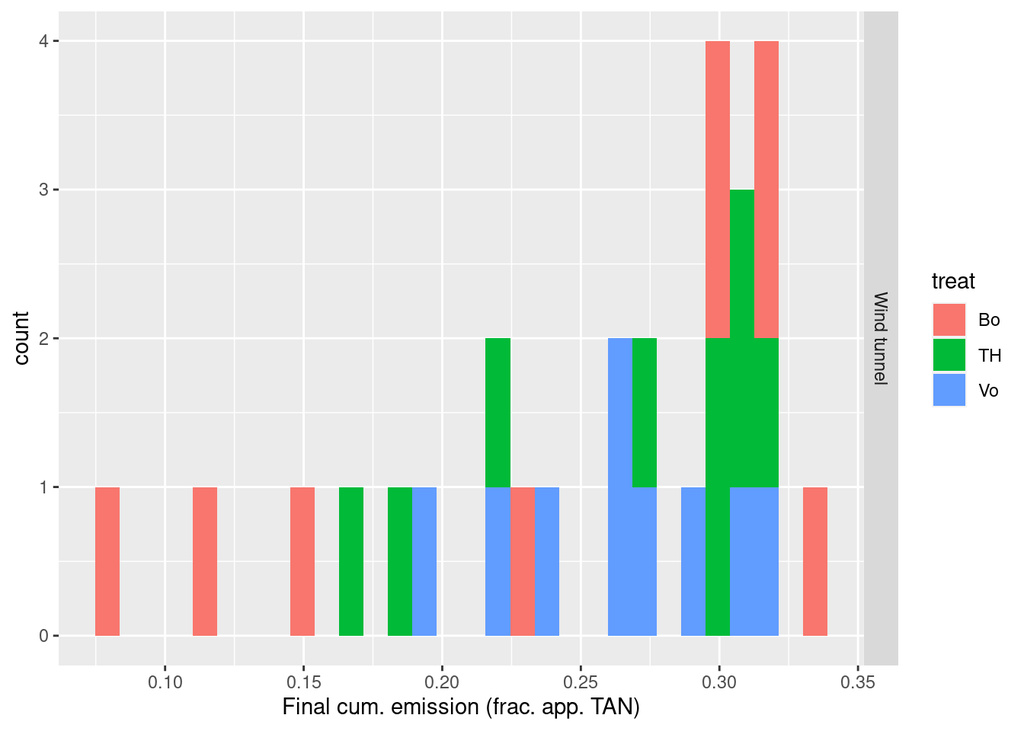

## Relative versus absolute emission

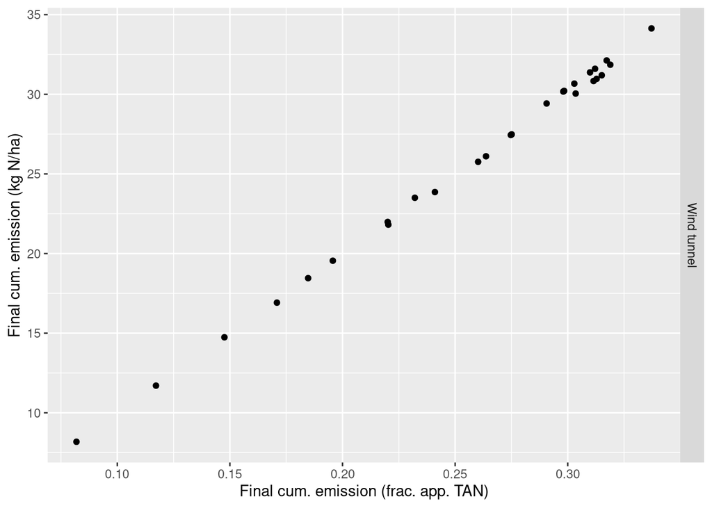

## Flux

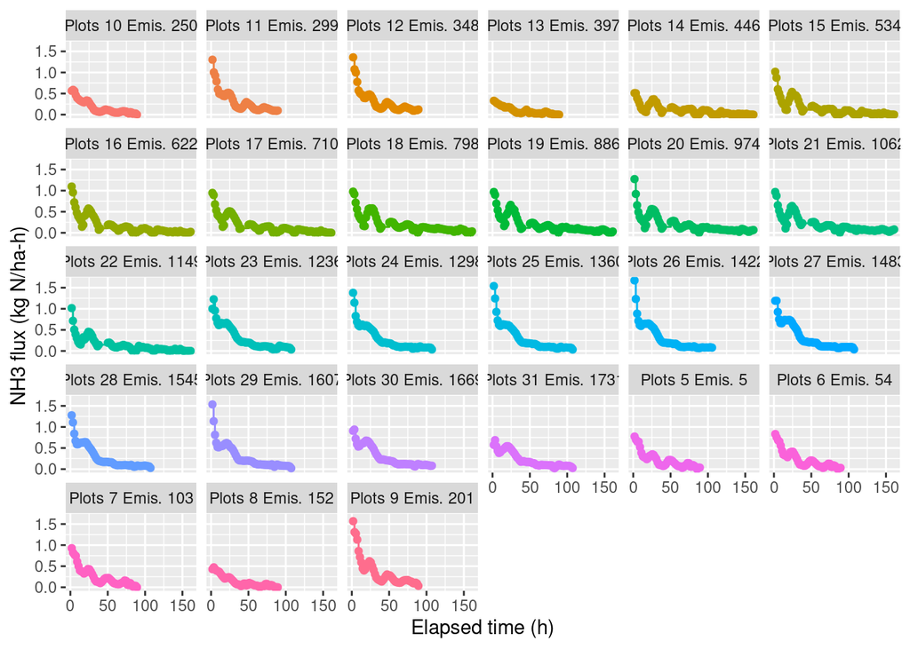

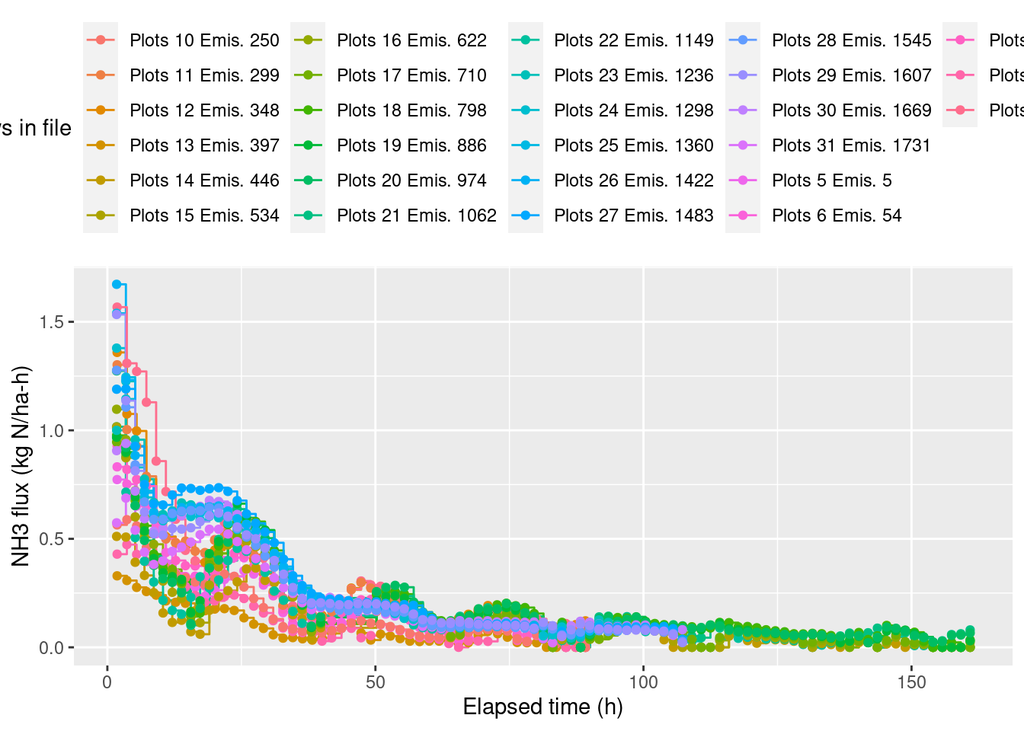

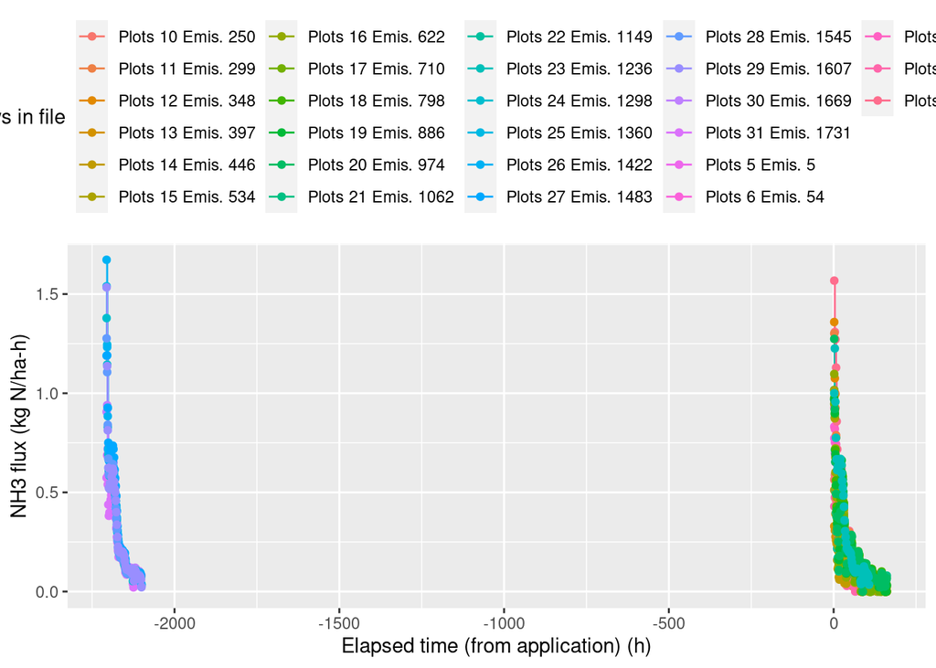

## Weather data

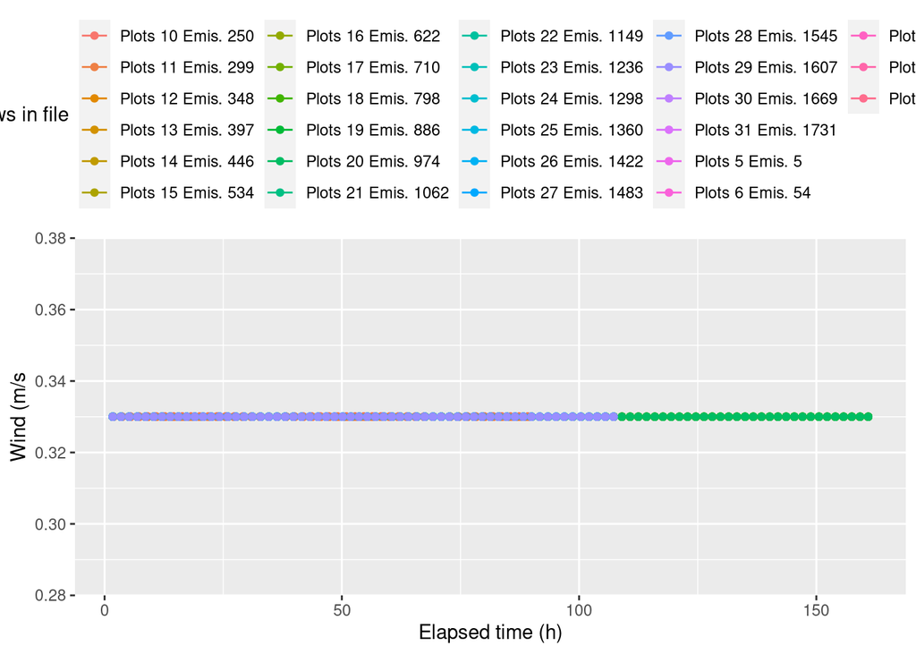

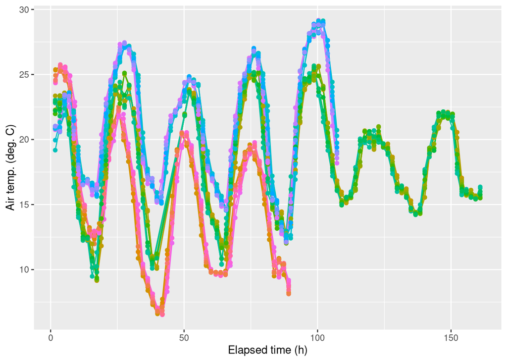

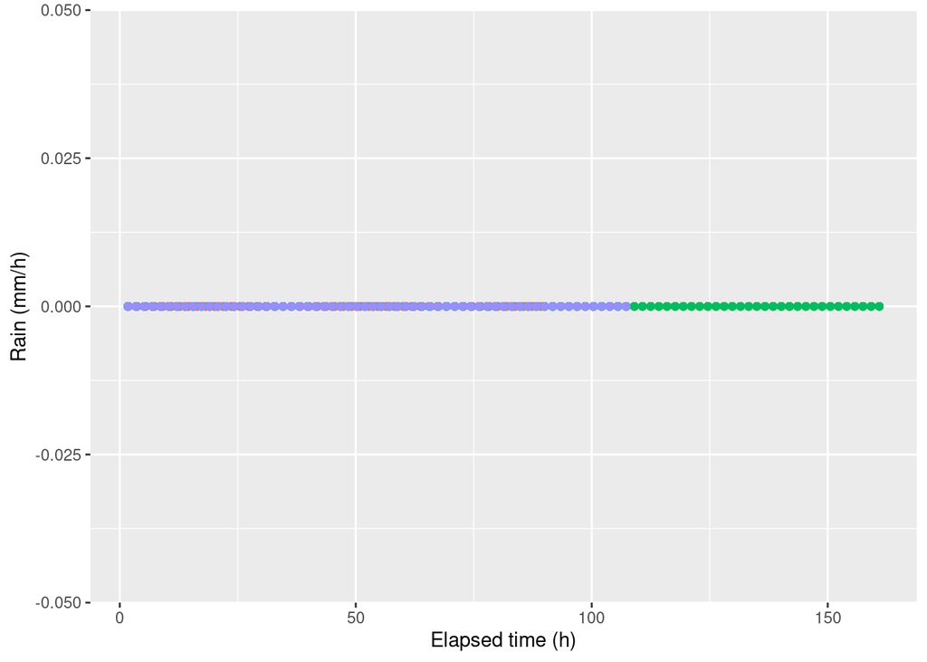

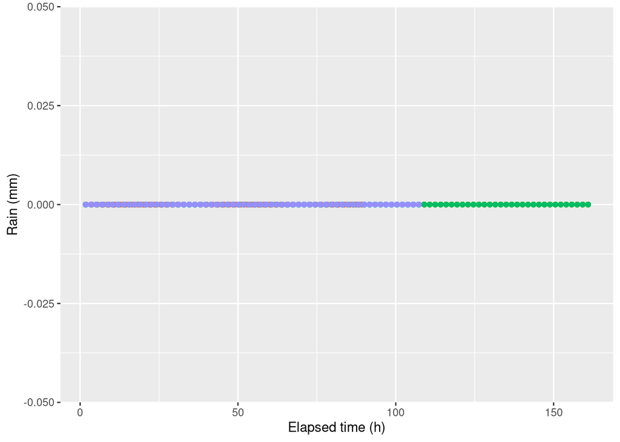

## Manure and application

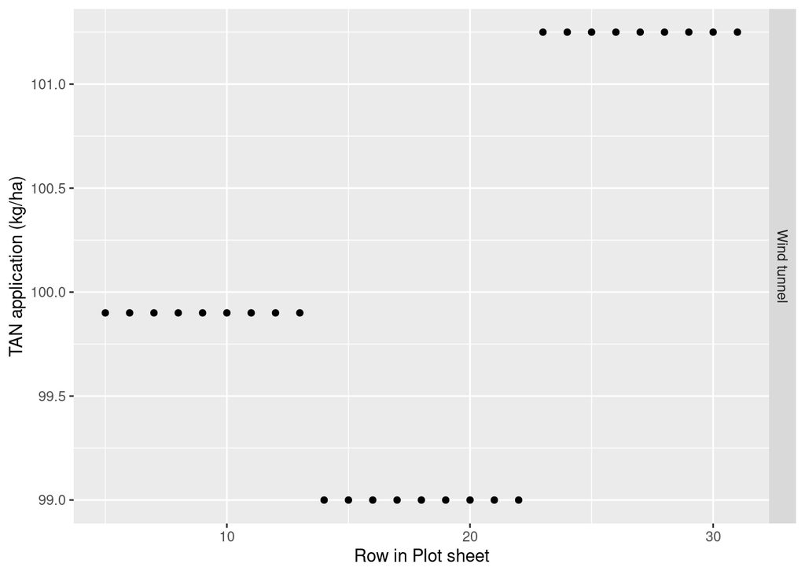

# 10. `dfsumm` summary

```
##
##  1788 rows and 135 columns
##  1788 unique rows
##                                                                                                                                                                                          cpmid
## Class                                                                                                                                                                                character
## Minimum            D:1.I:AU.Pr:NUGA.F:../../data-submitted/03/AU/ALFAM2_template_5_2_211012_JP_18ABC.xlsx.E:18A.F:semi-field facilities.P:1.T:TH.R:1.R2:.T:2018-05-15 13:18:00.M:Wind tunnelNA
## Maximum            D:1.I:AU.Pr:NUGA.F:../../data-submitted/03/AU/ALFAM2_template_5_2_211012_JP_18ABC.xlsx.E:18C.F:semi-field facilities.P:9.T:TH.R:3.R2:.T:2018-08-29 14:04:00.M:Wind tunnelNA
## Mean                                                                                                                                                                                      <NA>
## Unique (excld. NA)                                                                                                                                                                          27
## Missing values                                                                                                                                                                               0
## Sorted                                                                                                                                                                                    TRUE
##
##                       pub.id      proj     exper                 field    plot
## Class              character character character             character numeric
## Minimum                    A      NUGA       18A semi-field facilities       1
## Maximum                    A      NUGA       18C semi-field facilities      12
## Mean                    <NA>      <NA>      <NA>                  <NA>    6.33
## Unique (excld. NA)         1         1         3                     1       9
## Missing values             0         0         0                     0       0
## Sorted                  TRUE      TRUE      TRUE                  TRUE   FALSE
##
##                        rep     treat   meas.tech meas.tech.det plot.area
## Class              numeric character   character       logical   numeric
## Minimum                  1        Bo Wind tunnel          <NA>       0.2
## Maximum                  3        Vo Wind tunnel          <NA>       0.2
## Mean                     2      <NA>        <NA>          <NA>       0.2
## Unique (excld. NA)       3         3           1             0         1
## Missing values           0         0           0          1788         0
## Sorted               FALSE     FALSE        TRUE          <NA>      TRUE
##
##                        lat    long   country      topo    clay    silt    sand
## Class              numeric numeric character character numeric numeric numeric
## Minimum               56.5    9.58        DK      Flat       4       5      49
## Maximum               56.5    9.58        DK      Flat      18      31      89
## Mean                  56.5    9.58      <NA>      <NA>    10.6    21.5    65.9
## Unique (excld. NA)       1       1         1         1       3       3       3
## Missing values           0       0         0         0       0       0       0
## Sorted                TRUE    TRUE      TRUE      TRUE    TRUE    TRUE   FALSE
##
##                         oc soil.type soil.water soil.water.v soil.moist soil.ph
```

[output cut: 488 more lines]

```
## Maximum                     ts        None 2018-05-15          1730       31
## Mean                      <NA>        <NA>       <NA>           864     18.6
## Unique (excld. NA)           2           1          1            27       27
## Missing values               0           0          0             0        0
## Sorted                   FALSE        TRUE       TRUE         FALSE    FALSE
##
##                             first.rows
## Class                           factor
## Minimum             Plots 10 Emis. 250
## Maximum              Plots 9 Emis. 201
## Mean               Plots 22 Emis. 1149
## Unique (excld. NA)                  27
## Missing values                       0
## Sorted                           FALSE
##
```